# 3. Data Pre-processing

Data pre-processing techniques generally refer to the addition, deletion, or transformation of training set data. Different models have different sensitivities to the type of predictors in the model; *how* the predictors enter the model is also important. The need for data pre-processing is determined by the type of model being used. Some procedures, such as tree-based models, are notably insensitive to the characteristics of the predictor data. Others, like linear regression, are not.... discuss a wide array of possible methodologies.

Transformations of the data to reduce the impact of data skewness or outliers can lead to significant improvements in performance.

How the predictors are encoded, called *feature engineering* (one empirical technique for creating surrogate variables that are combinations of multiple predictors), can have a significant impact on model performance.

Additionally, simpler strategies such as removing predictors based on their lack of information content can also be effective.

Often the most effective encoding of the data is informed by the modeler's understanding of the problem and thus is not derived from any mathematical techniques.

Discuss approaches to unsupervised data processing: the outcome variable is not considered by the pre-processing techniques (versussupervised methods, where the outcome is utilized to pre-process the data. For example, partial least squares (PLS) models are essentially supervised versions of principal component analysis (PCA).

Here describe strategies for removing predictors without considering how those variables might be related to the outcome.

## 3.1 Case Study: Cell Segmentation in High-Content Screening

Check if data exists.

```python
import numpy as np
import pandas as pd
```

```python
cell_segmentation = pd.read_csv("E:/2020_Classes/BA/19AI704_Applied Predictive Analytics/Data/segmentation/segmentationOriginal.csv")
```

This dataset is from Hill et al. (2007) that consists of 2019 cells. Of these cells, 1300 were judged to be poorly segmented (PS) and 719 were well segmented (WS); 1009 cells were reserved for the training set.

```python
cell_segmentation.shape
```

```
(2019, 119)
```

A first look at the dataset.

```python
cell_segmentation.head(5)
```

|  | Cell | Case | Class | AngleCh1 | AngleStatusCh1 | AreaCh1 | AreaStatusCh1 | AvgIntenCh1 | AvgIntenCh2 | AvgIntenCh3 | ... | VarIntenCh1 | VarIntenCh3 | VarIntenCh4 | VarIntenStatusCh1 | VarIntenStatusCh3 | VarIntenStatusCh4 | WidthCh1 | WidthStatusCh1 | XCentroid | YCentroid |
| --- | --- | --- | --- | --- | --- | --- | --- | --- | --- | --- | --- | --- | --- | --- | --- | --- | --- | --- | --- | --- | --- |
| 0 | 207827637 | Test | PS | 143.247705 | 1 | 185 | 0 | 15.711864 | 3.954802 | 9.548023 | ... | 12.474676 | 7.609035 | 2.714100 | 0 | 2 | 2 | 10.642974 | 2 | 42 | 14 |
| 1 | 207932307 | Train | PS | 133.752037 | 0 | 819 | 1 | 31.923274 | 205.878517 | 69.916880 | ... | 18.809225 | 56.715352 | 118.388139 | 0 | 0 | 0 | 32.161261 | 1 | 215 | 347 |
| 2 | 207932463 | Train | WS | 106.646387 | 0 | 431 | 0 | 28.038835 | 115.315534 | 63.941748 | ... | 17.295643 | 37.671053 | 49.470524 | 0 | 0 | 0 | 21.185525 | 0 | 371 | 252 |
| 3 | 207932470 | Train | PS | 69.150325 | 0 | 298 | 0 | 19.456140 | 101.294737 | 28.217544 | ... | 13.818968 | 30.005643 | 24.749537 | 0 | 0 | 2 | 13.392830 | 0 | 487 | 295 |
| 4 | 207932455 | Test | PS | 2.887837 | 2 | 285 | 0 | 24.275735 | 111.415441 | 20.474265 | ... | 15.407972 | 20.504288 | 45.450457 | 0 | 0 | 0 | 13.198561 | 0 | 283 | 159 |

5 rows × 119 columns

We will use the training set samples to demonstrate data pre-processing techniques.

```python
cell_segmentation.groupby('Case').count()
```

| Case | Cell | Class | AngleCh1 | AngleStatusCh1 | AreaCh1 | AreaStatusCh1 | AvgIntenCh1 | AvgIntenCh2 | AvgIntenCh3 | AvgIntenCh4 | ... | VarIntenCh1 | VarIntenCh3 | VarIntenCh4 | VarIntenStatusCh1 | VarIntenStatusCh3 | VarIntenStatusCh4 | WidthCh1 | WidthStatusCh1 | XCentroid | YCentroid |
| --- | --- | --- | --- | --- | --- | --- | --- | --- | --- | --- | --- | --- | --- | --- | --- | --- | --- | --- | --- | --- | --- |
| Test | 1010 | 1010 | 1010 | 1010 | 1010 | 1010 | 1010 | 1010 | 1010 | 1010 | ... | 1010 | 1010 | 1010 | 1010 | 1010 | 1010 | 1010 | 1010 | 1010 | 1010 |
| Train | 1009 | 1009 | 1009 | 1009 | 1009 | 1009 | 1009 | 1009 | 1009 | 1009 | ... | 1009 | 1009 | 1009 | 1009 | 1009 | 1009 | 1009 | 1009 | 1009 | 1009 |

2 rows × 118 columns

```python
# separate training and test data
cell_train = cell_segmentation[cell_segmentation['Case'] == 'Train']
cell_test = cell_segmentation[cell_segmentation['Case'] == 'Test']

cell_train.head(5)
```

|  | Cell | Case | Class | AngleCh1 | AngleStatusCh1 | AreaCh1 | AreaStatusCh1 | AvgIntenCh1 | AvgIntenCh2 | AvgIntenCh3 | ... | VarIntenCh1 | VarIntenCh3 | VarIntenCh4 | VarIntenStatusCh1 | VarIntenStatusCh3 | VarIntenStatusCh4 | WidthCh1 | WidthStatusCh1 | XCentroid | YCentroid |
| --- | --- | --- | --- | --- | --- | --- | --- | --- | --- | --- | --- | --- | --- | --- | --- | --- | --- | --- | --- | --- | --- |
| 1 | 207932307 | Train | PS | 133.752037 | 0 | 819 | 1 | 31.923274 | 205.878517 | 69.916880 | ... | 18.809225 | 56.715352 | 118.388139 | 0 | 0 | 0 | 32.161261 | 1 | 215 | 347 |
| 2 | 207932463 | Train | WS | 106.646387 | 0 | 431 | 0 | 28.038835 | 115.315534 | 63.941748 | ... | 17.295643 | 37.671053 | 49.470524 | 0 | 0 | 0 | 21.185525 | 0 | 371 | 252 |
| 3 | 207932470 | Train | PS | 69.150325 | 0 | 298 | 0 | 19.456140 | 101.294737 | 28.217544 | ... | 13.818968 | 30.005643 | 24.749537 | 0 | 0 | 2 | 13.392830 | 0 | 487 | 295 |
| 11 | 207932484 | Train | WS | 109.416426 | 0 | 256 | 0 | 18.828571 | 125.938776 | 13.600000 | ... | 13.922937 | 18.643027 | 40.331747 | 0 | 0 | 2 | 17.546861 | 0 | 211 | 495 |
| 14 | 207932459 | Train | PS | 104.278654 | 0 | 258 | 0 | 17.570850 | 124.368421 | 22.461538 | ... | 12.324971 | 17.747143 | 41.928533 | 0 | 0 | 2 | 17.660339 | 0 | 172 | 207 |

5 rows × 119 columns

## Part1- Data Transformation for Individual Predictors

Transformations of predictor variables may be needed for several reasons. Some modeling techniques may have strict requirements, such as the predictors having a commom scale. In other cases, creating a good model may be difficult due to specific characteristics of the data (e.g., outliers).

### Centering and Scaling

To center a predictor variable, the average predictor value is substracted from all the values. As a result of centering, the predictor has a zero mean. Similarly, to scale the data, each value of the predictor variable is divided by its standard deviation. Scaling the data coerce the values to have a common standard deviation of one. These manipulations are generally used to improve the numerical stability of some calculations, such as partial least squares,PLS. The only real downside to these transformation is a loss of interpretability of the individual values.

### Transformations to Resolve Skewness

An un-skewed distribution is one that is roughly symmetric. A rule of thumb to consider is that skewed data whose ratio of the highest value to the lowest value is greater than 20 have significant skewness. The sample skewness statistic is defined $$\text{skewness} = {\sum (x_i - \bar{x})^3 \over (n - 1) v^{3/2}},$$ where $$v = {\sum (x_i - \bar{x})^2 \over (n - 1)}.$$ Note that the skewness for a normal distribution is zero.

The cell segmentation data contain a predictor that measures the standard deviation of the intensity of the pixels in the actin filaments.

```python
%matplotlib inline
import matplotlib.pyplot as plt
```

```python
# Some nice default configuration for plots
plt.rcParams['figure.figsize'] = 10, 7.5
plt.rcParams['axes.grid'] = True
plt.gray()
```

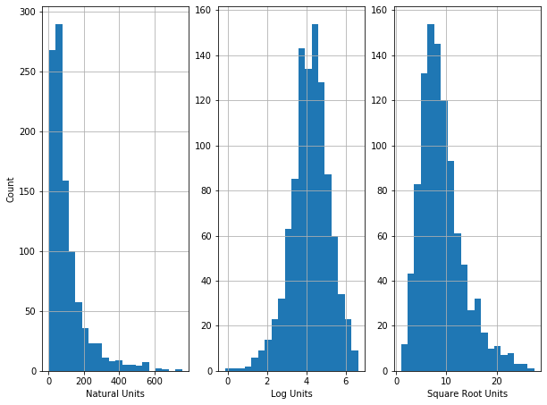

```python
fig, (ax1, ax2, ax3) = plt.subplots(1, 3)

ax1.hist(cell_train['VarIntenCh3'].values, bins=20)
ax1.set_xlabel('Natural Units')
ax1.set_ylabel('Count')

ax2.hist(np.log(cell_train['VarIntenCh3'].values), bins=20)
ax2.set_xlabel('Log Units')

ax3.hist(np.sqrt(cell_train['VarIntenCh3'].values), bins=20)
ax3.set_xlabel('Square Root Units')
```

The histogram shows a strong right skewness. The log transformation seems to work well for this dataset. The ratio of the smallest to largest value and the sample skewness statistic all agree with the histogram under natural units.

```python
from scipy.stats import skew
r = np.max(cell_train['VarIntenCh3'].values)/np.min(cell_train['VarIntenCh3'].values)
skewness = skew(cell_train['VarIntenCh3'].values)
skewness
```

```
2.3951841812380814
```

Skewness statistic was calculated to be 2.39 while the ratio to the largest and smallest value was 870. The same data after a log transformation, the skewness value was −0.4

Alternatively, statistical models can be used to empirically identify an appropriate transformation. One of the most famous transformations is the Box-Cox family, i.e. \begin{equation} x^* = \begin{cases} {x^{\lambda}-1 \over \lambda} & \text{if} \ \lambda \neq 0 \\ log(x) & \text{if} \ \lambda = 0 \end{cases} \end{equation} This family covers the log ($\lambda = 0$), square ($\lambda = 2$), square root ($\lambda = 0.5$), inverse ($\lambda = -1$), and others in-between. Using the training data, $\lambda$ can be estimated using maximum likelihood estimation (MLE). This procedure would be applied independently to each predictor data that contain values **greater than 0**.

The boxcox() in *scipy.stats* finds the estimated lambda and performs the transformation at the same time.

For the segmentation data, 69 predictors were not transformed due to zero or negative values and 3 predictors had λ estimates within 1 ± 0.02,so no transformation was needed.

[figure not shown]

```python
from scipy.stats import boxcox
boxcox(cell_train['VarIntenCh3'].values)[1]
#print 'Estimated lambda is {0}'.format(boxcox(cell_train['VarIntenCh3'].values)[1])
```

```
0.1215319467853224
```

Take another predictor for example.

Another predictor, the estimated cell perimeter,had a λ estimate of −1.1. For these data, the original and transformed values(inverse )are shown in Fig.

```
-1.0912843623038573
```

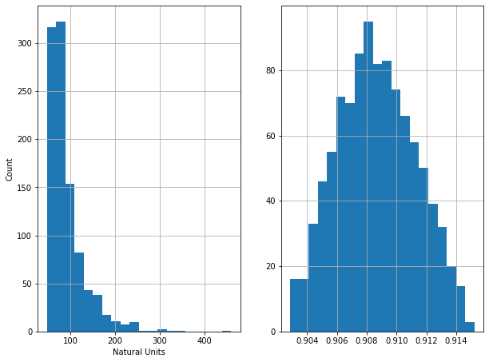

```python
fig, (ax1, ax2) = plt.subplots(1, 2)

ax1.hist(cell_train['PerimCh1'].values, bins=20)
ax1.set_xlabel('Natural Units')
ax1.set_ylabel('Count')

ax2.hist(boxcox(cell_train['PerimCh1'].values)[0], bins=20)
boxcox(cell_train['PerimCh1'].values)[1]
```